# Assignment 3

2. Summarize this further – average the mean RTs and plot these new group-level means in a bar graph, split into 8 conditions defined by combinations of groupCue and wbn conditions. The bars should be clustered by grouping cue. I.e., the x-axis corresponding to the grouping cues, with the within and between conditions for that cue plotted side by side. Plot error bars defined by standard error.

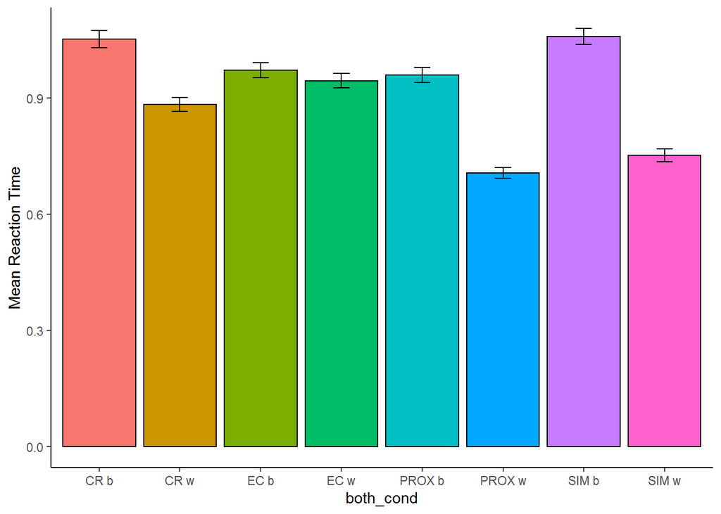

```r
# x-axis = grouping cues where the within and between conditions are side by side
# based on this, I should average across participants

# take the mean and sem of all conditions and save for bar graph

bar_df = df_RTs %>%
  group_by(groupCue, wbn) %>%
  summarise_at(c("meanRT"),funs(mean,sem=sd(.)/sqrt(n())))
bar_df = mutate(bar_df, both_cond = paste(groupCue, wbn)) # combine columns for plotting

# plot with ggplot

ggplot(bar_df, aes(y = mean, x = both_cond, fill = both_cond))+
  geom_bar(stat="identity", color="black", position=position_dodge()) +
  geom_errorbar(aes(ymin = mean-sem, ymax = mean+sem), width=.2, position=position_dodge(.9)) +
  theme_classic() + theme(legend.position = "none") +
  ylab("Mean Reaction Time")
```

```r
  xlab("Condition Combinations")
```

```
## $x
## [1] "Condition Combinations"
##
## attr(,"class")
## [1] "labels"
```

3. RM-ANOVA. Use ezANOVA to run a repeated-measures ANOVA on the data in df_RTs, with 2 within-subjects factors: wbn and groupCue. You don’t have to write up the results but make sure the ezANOVA output table displays. Ask ezANOVA to give detailed output that includes SS terms.

```r
library(ez) # load library
df_RTs$participant = as.factor(df_RTs$participant) # convert to factor

# reformat
library(dplyr)
df_RTs = df_RTs %>% arrange(groupCue,wbn)

# run anova using ezANOVA

dfRT_anova = ezANOVA(
    data       = df_RTs
    , dv       = meanRT                 # dv
    , wid      = participant            # subjects
    , within   = .(groupCue,wbn)        # within subjects factors
    , detailed = TRUE
    , type     = 3
)
# print out detailed output that includes SS data

print(dfRT_anova)
```

```
## $ANOVA
##         Effect DFn DFd        SSn       SSd         F            p p<.05
## 1  (Intercept)   1 104 703.854014 26.106250 2803.9576 4.778485e-77     *
## 2     groupCue   3 312   2.394788  1.318360  188.9149 7.963737e-70     *
## 3          wbn   1 104   7.491368  1.883050  413.7448 4.917708e-38     *
## 4 groupCue:wbn   3 312   2.335140  1.395709  174.0008 2.723613e-66     *
##          ges
## 1 0.95820154
## 2 0.07235410
## 3 0.19613613
## 4 0.07067935
##
## $`Mauchly's Test for Sphericity`
##         Effect        W         p p<.05
## 2     groupCue 0.925035 0.1560066
## 4 groupCue:wbn 0.910814 0.0875419
##
## $`Sphericity Corrections`
##         Effect       GGe        p[GG] p[GG]<.05       HFe        p[HF]
## 2     groupCue 0.9533492 1.058506e-66         * 0.9831426 1.070987e-68
## 4 groupCue:wbn 0.9466027 6.644466e-63         * 0.9759433 9.144138e-65
##   p[HF]<.05
## 2         *
## 4         *
```

```r
# for checking

#setwd("C:/Users/uggriffin/Documents/R/R stats course/Assignments")
#write.csv(df_RTs,"df_RTs.csv")
```

4. The RM-ANOVA in this case is kind of beside the point – because we have a priori hypotheses, we wouldn’t start with this analysis. That said, if you saw the outcome of an ANOVA that looked like what you see in (3), what would your next step be? Answer below in bold text. Though we haven’t done a 2-factor RM-ANOVA in class the idea is the same as with between-groups ANOVA. However, there is one wrinkle – you are not recommended to pool variance in follow-up tests for repeated measures, as it can inflate type I error rates in some cases. So, you would just follow up with independent tests – I’m just asking what would make sense in this case, not for you to actually perform these.

** In this situation, we’re mostly interested in the effect of different groupings on mean reaction time. With that being said, an argument could be made for only diving into the interaction effect noted above. The simplest approach in my mind would be to run independent paired t-tests between the grouped conditions (i.e. SIM-b VS SIM-w) and correcting for the p-value accordingly. This approach feels approriate for a few reasons: 1) this data is paired, each subject received the same manipulations and our interest is the effect of combinations of independent variables on the mean reaction times 2) paired t-tests across all combinations seem over-kill and could inflate the type 2 error after corrected for all tests and 3) we don’t have to make any assumptions regarding variance with the paired t-test. **

5. In the ANOVA above, what key thing would change if this had been a betweeen-subjects study? That is, if you ran ezANOVA with these factors as between-subjects, what would be the key reason you would likely obtain lower F values?

## RM-ANOVA equations

> - $n$ is the number of subjects, $k$ is levels of the variable $A$.
> - $X_{ij}$ is the score of subject $i$ on level $j$.
> - $X_{i.}$ is mean for subject $i$. $X_{.j}$ is mean for level $j$.
> - $X_{..}$ is the grand mean.
> - $SS_{within} = \sum_{i=1}^n{\sum_{j=1}^k{(X_{ij}-X_i.)^2}}$
> - $SS_{A} = n\sum_{j=1}^k{(X.j-X..)^2}$
> - $SS_{error} = SS_{within} - SS_{A}$

## RM-ANOVA equations

> - $SS_{within} = \sum_{i=1}^n{\sum_{j=1}^k{(X_{ij}-X_i.)^2}}$
> - $SS_{A} = n\sum_{j=1}^k{(X.j-X..)^2}$
> - $SS_{within-error} = SS_{within} - SS_{A}$
> - $df_{A} = k-1$
> - $df_{within-error} = (k-1)*(n-1)$
> - $MS_A$ and $MS_{within-error}$ are just $SS$ terms divided by corresponding $df$ terms.
> - $F = \frac{MS_{A}}{MS_{within-error}}$
> - Between-subjects error is not considered at all for factor A!

EXTRA CREDIT: Our real hypothesis is that there will be systematic variation amongst the four grouping types. We expect, specifically, that the CR cue and the EC cue will produce similar effects within individuals. Calculate correlations between the grouping effect (between minus within RT) for each factor and each other factor. This will involve a total of 4 correlations. Do you see a pattern?